# Exploring univariate patterns

### Exercise 8: Visualizing a quantitative variable: histograms (part 2)

Separately run each chunk below and add a comment (`#`) about what you see.

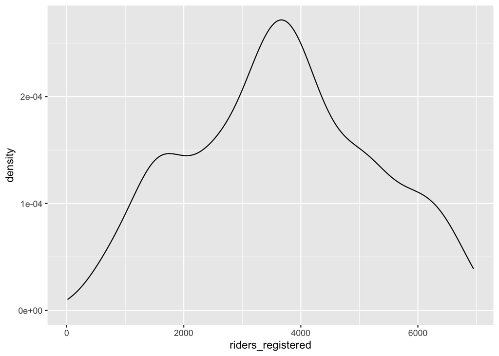

```r
# gives the density function for riders registered
ggplot(bikes, aes(x = riders_registered)) +
  geom_density()
```

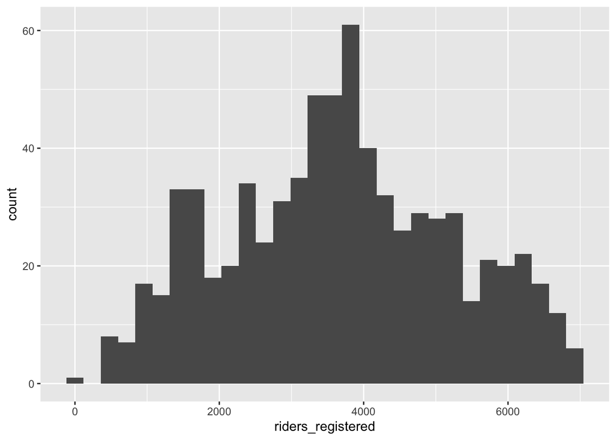

```r
# creates a histogram for riders_registered
ggplot(bikes, aes(x = riders_registered)) +
  geom_histogram()
```

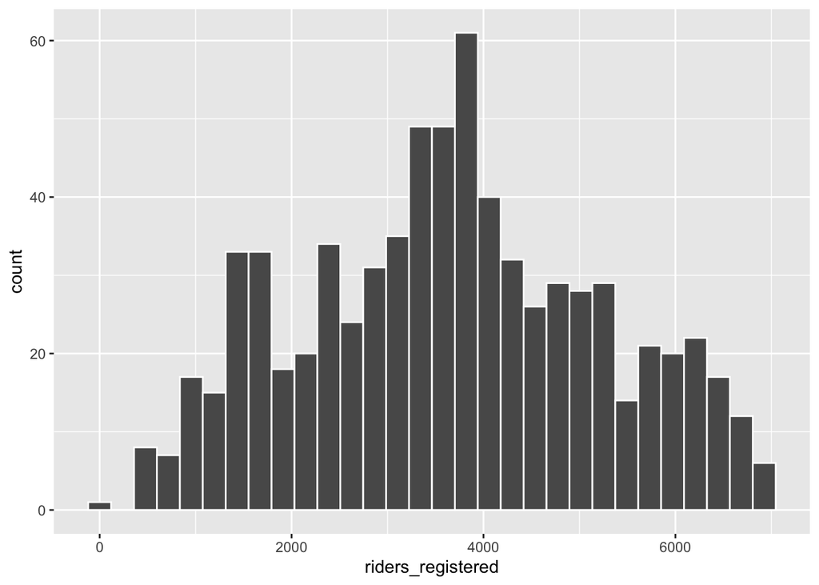

```r
# Recolors border between bins
ggplot(bikes, aes(x = riders_registered)) +
  geom_histogram(color = "white")
```

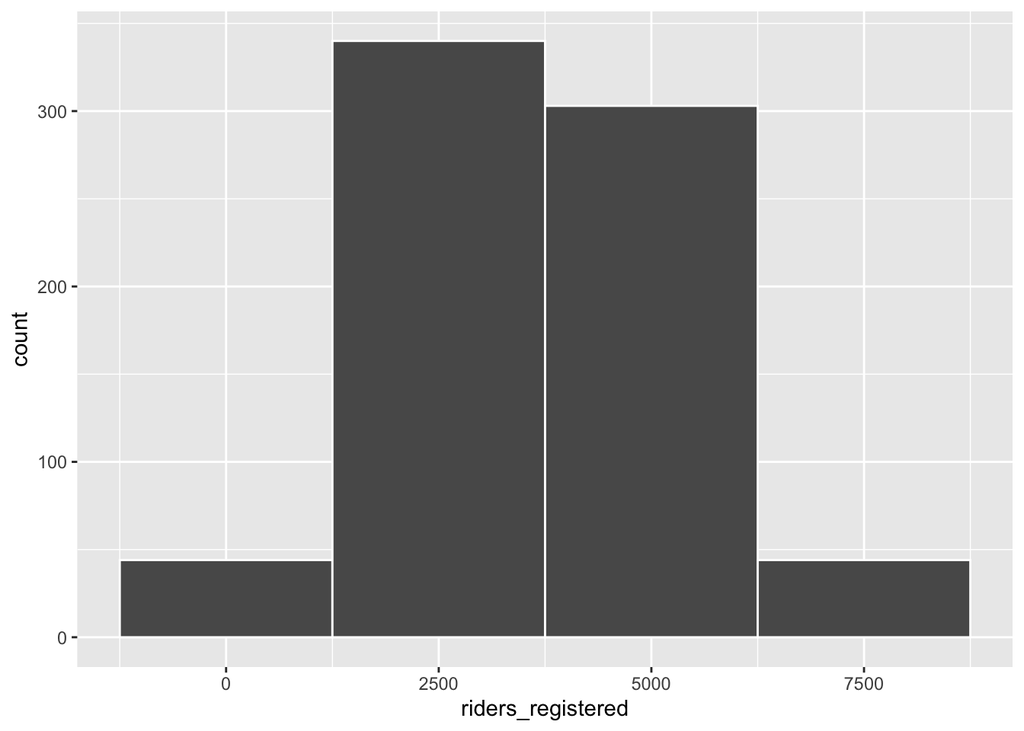

```r
# huge bins with border
ggplot(bikes, aes(x = riders_registered)) +
  geom_histogram(color = "white", binwidth = 2500)
```

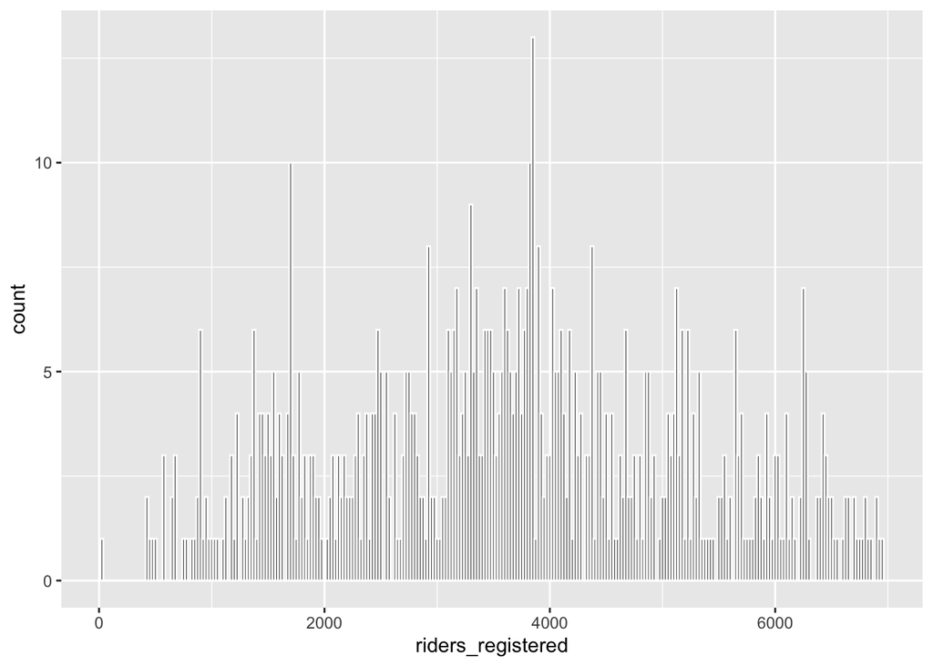

```r
# Tiny bordered bins
ggplot(bikes, aes(x = riders_registered)) +
  geom_histogram(color = "white", binwidth = 25)
```

### Exercise 9: Reflection: goldilocks!

The different histograms visualized the *same data* but look quite different. Which of the histograms provided you with the “best” insights into ridership? Why? That is, what are the trade-offs in using small vs large bins?

**Fun fact:** Choosing bin widths is a “goldilocks problem”. Just like the Goldilocks character in a strange fairy tale about 3 bears, we don’t want bins that are too wide or too narrow, but bins that are just right.

[figure not shown]

*Wikimedia commons*

### Exercise 10: Numerical summaries

Whereas the `ggplot2` package is great for visualizations, `dplyr` is great for numerical summaries. Play around and comment on what you see:

```r
# Load package
library(dplyr)
# shows a table with the mean
bikes %>%
  summarize(mean(riders_registered))
```

```
##   mean(riders_registered)
## 1                3656.172
```

```r
# shows a table with the mean and median
bikes %>%
  summarize(mean(riders_registered), median(riders_registered))
```

```
##   mean(riders_registered) median(riders_registered)
## 1                3656.172                      3662
```

```r
# shows two tables with min/max and standard deviation
bikes %>%
  summarize(min(riders_registered), max(riders_registered))
```

```
##   min(riders_registered) max(riders_registered)
## 1                     20                   6946
```

```r
bikes %>%
  summarize(sd(riders_registered))
```

```
##   sd(riders_registered)
## 1              1560.256
```

### Exercise 11: Your turn!

Construct and interpret visual and numerical summaries of some other variables in the data set:

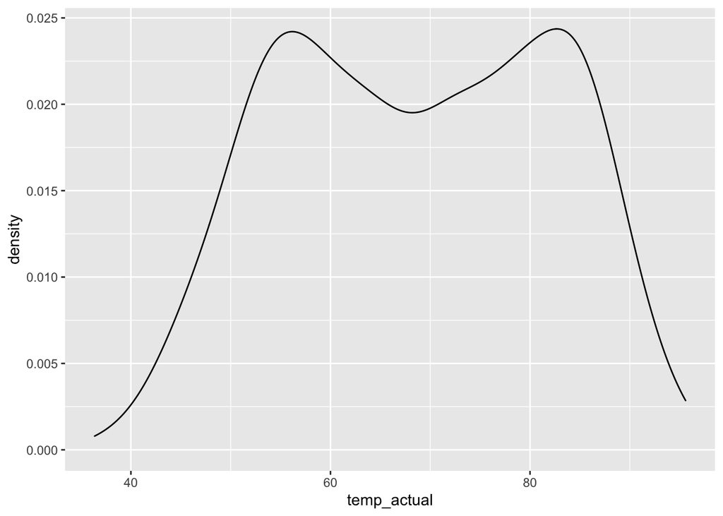

```r
# Plot stub
base_plot <- bikes %>%
    ggplot(aes(x = temp_actual))

# Construct a plot of temp_actual
base_plot + geom_density()
```

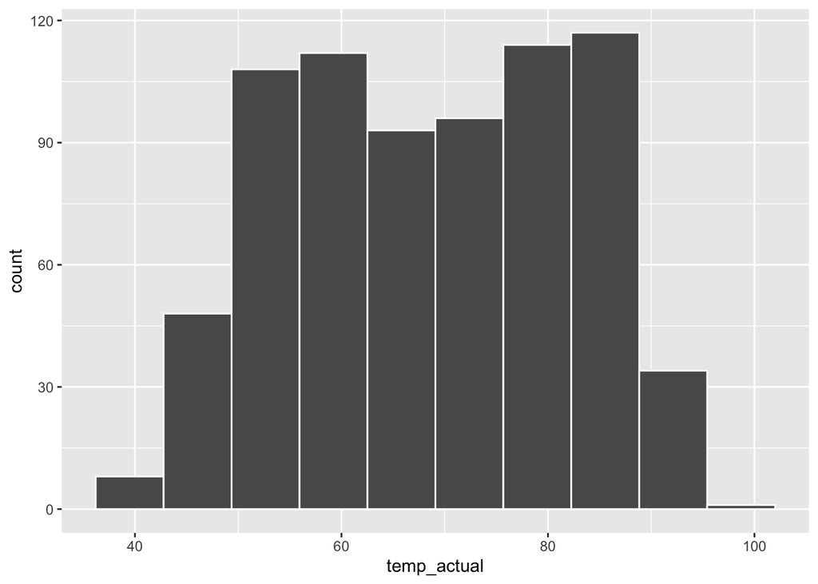

```r
# Construct another plot of temp_actual using a different technique
base_plot + geom_histogram(bins = 10, color = "white")
```

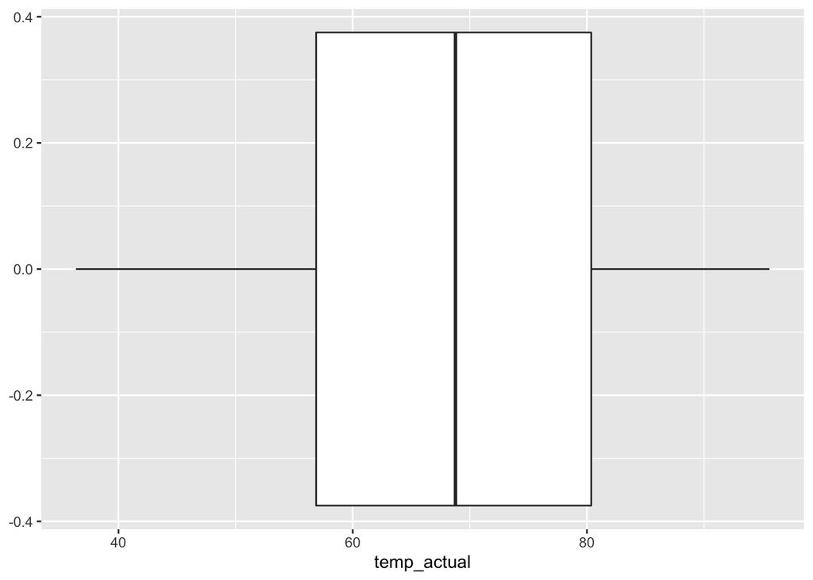

```r
# Construct yet another plot of temp_actual using yet a different technique
base_plot + geom_boxplot()
```

```r
# Calculate summaries of the trend in DC temperatures)
bikes %>%
  summarise(mean(temp_feel), IQR(temp_feel))
```

```
##   mean(temp_feel) IQR(temp_feel)
## 1        74.69186       24.36836
```

```r
# Calculate summaries of the variability in DC temperatures
bikes %>%
  summarize(min(temp_feel), max(temp_feel))
```

```
##   min(temp_feel) max(temp_feel)
## 1       39.11626       107.6806
```

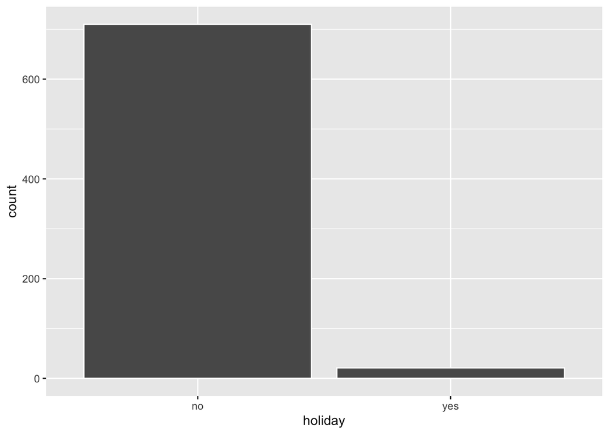

```r
# Construct a plot of holiday
bikes %>%
  ggplot(aes(x = holiday)) +
  geom_bar(color = "white")
```

### Exercise 12: Different ways to think about data visualization

In working with and visualizing data, it’s important to keep in mind what a data point *represents*. It can reflect the experience of a real person. It might reflect the sentiment in a piece of art. It might reflect history. We’ve taken one very narrow and technical approach to data visualization. Check out the following examples. You will use them as inspiration for the next question of the week!

- [decolonizing data viz](https://stephanieevergreen.com/decolonizing-data-viz/)
- [dear data](http://www.dear-data.com/by-week)
- [W.E.B. DuBois](https://hyperallergic.com/476334/how-w-e-b-du-bois-meticulously-visualized-20th-century-black-america/)
- [phase change project (by Prof Kim, Mac research students)](http://www.variableprojects.com/#/phase-change/)

### Exercise 13: Clean, knit, and save your work!

$$\mathcal{Done!}$$

## Optional: digging deeper

The above exercises are designed to help you practice the foundational concepts in this course. To build a deeper understanding and practice, you’re encouraged to consider the following exercises as well. I trust that you will make the best decision for yourself at this particular time.

### Exercise 14: Grammar

Think of the first language you learned. Though you certainly haven’t memorized every word in that language, your understanding of syntax, grammar, and sentence structure provide the necessary foundation for communication. You can also build upon this foundation (eg: learn new words) as needed. Similarly, statistical “programming” is a language. It has a syntax, grammar, and vocabulary. With that:

1. Summarize your observations about the `ggplot` grammar. For example:
   - what is the first argument we specify?
   - what do you think `aes` stands for and what info do we put inside `aes()`?
   - when do we end lines with `+`? when don’t we?
   - what’s the purpose of the second row of `ggplot()` code? what does `geom` mean?
2. Summarize your observations about the `dplyr` grammar. For example: what’s the first thing we write? What do we put at the end of that line? What comes next?

### Exercise 15: Customizing!

Though you will naturally absorb some RStudio code throughout the semester, being an effective statistical thinker and “programmer” does not require that we memorize *all* code. That would be impossible. In contrast, we will focus on developing a foundation upon which we can build. Using the foundation you built today, do some digging online to learn how to customize your visualizations.

1. For the histogram below, add a title and more meaningful axis labels. Specifically, title the plot “My nice histogram”, change the x-axis label to “rides per day” and y-axis label to “number of days”. HINT: Do a Google search for something like “add axis labels ggplot”.

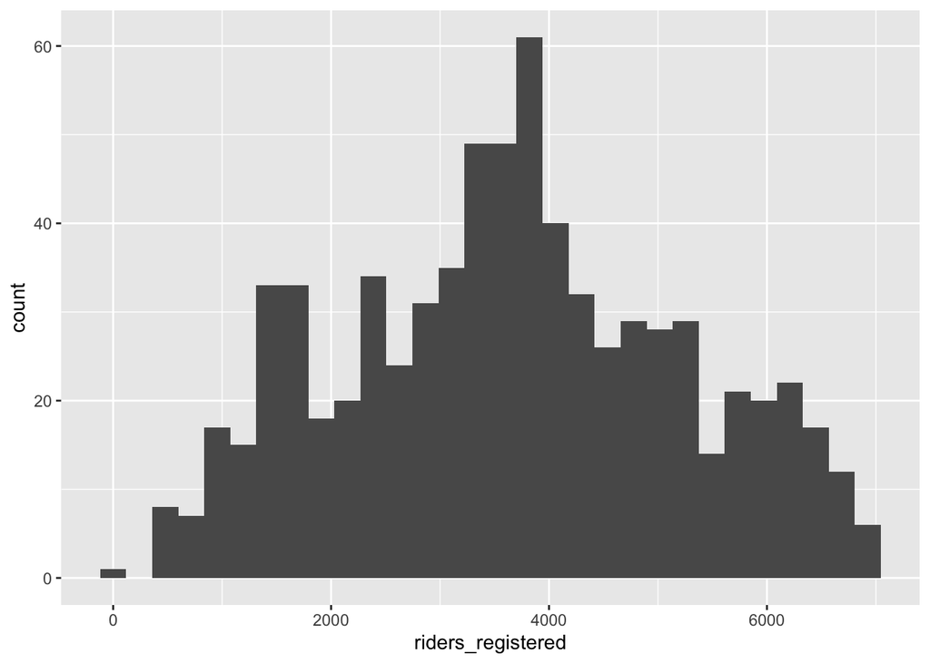

   ```r
   # Add a title and axis labels
   ggplot(bikes, aes(x = riders_registered)) +
     geom_histogram()
   ```

2. Adjust the code below in order to color the bars green. NOTE: Color can be an effective tool, but here it is simply gratuitous.

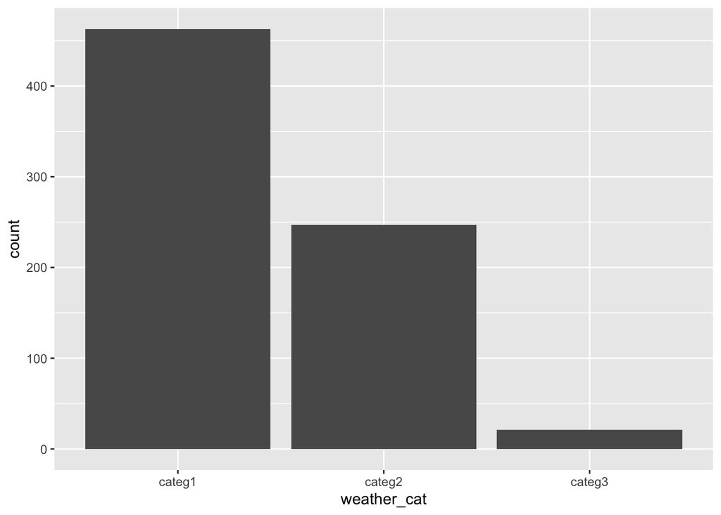

   ```r
   # Make the bars green
   ggplot(bikes, aes(x = weather_cat)) +
     geom_bar()
   ```

3. Check out the `ggplot2` cheat sheet in the [course manual appendix](https://rstudio.com/wp-content/uploads/2015/03/ggplot2-cheatsheet.pdf). Try making some of the other kinds of univariate plots outlined there.
4. What else would you like to change about your plot? Try it!